# Simulation of the Neutral Model

Eric Marcon

2026-09-13

# Data and tools

We want to build a species-rich metacommunity and a local, small community that is a sample of the metacommunity, according to the neutral model.

## Species

We will use letters to build the species names, e.g. “AAC”. Combining 3 letters, we’ll have $26^3 = 17576$ species names, i.e. more than the number of species in Amazonia (ter Steege et al. 2013).

To build the names, we use this code:

```r
library("tidyverse")
# LETTERS is the vector of capital letters A:Z
# outer() combines the first two args by FUN
LETTERS %>%
  outer(LETTERS, FUN = paste0) %>%
  # add a third letter
  outer(LETTERS, FUN = paste0) ->
  species_names
```

## Barro Colorado Island

We build a dataset according to BCI characteristics (Hubbell 2001): $\theta=50$ and $m=0.1$. The metacommunity follows a log-series distribution (Fisher et al. 1943). We build it with a billion trees. This size is arbitrary: the important parameter is $\theta$.

```r
mc_size <- 1E9
# theta is also Fisher's alpha
alpha <- 50
# Number of species (Fisher, 1943)
(-alpha * log(alpha / (mc_size + alpha))) %>%
  # integer needed
  as.integer() ->
  n_species
```

The metacommunity contains 840 species. We simulate their abundances.

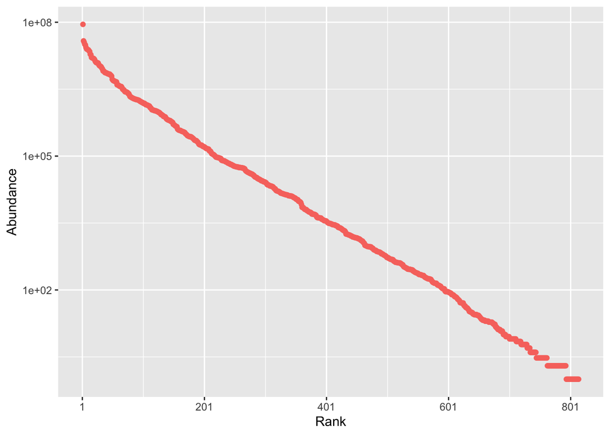

```r
library("divent")
rcommunity(
  # Simulate a single community
  1,
  # Number of trees
  size = mc_size,
  # Distribution: log-series
  distribution = "lseries",
  # Parameter
  fisher_alpha = alpha
) %>%
  # Set the species names
  rename_with(
    # Function of the selected columns:
    # return a subset of the species names vector
    function(x) species_names[seq_along(x)],
    # Select columns with species names
    starts_with("sp_")
  ) ->
  mc_abundances

# Rank-Abundance Curve
autoplot(mc_abundances, Distribution = "lseries")
```

## Local community

We draw a local community from the metacommunity. We give random positions to the trees in a square window to be able to see them later.

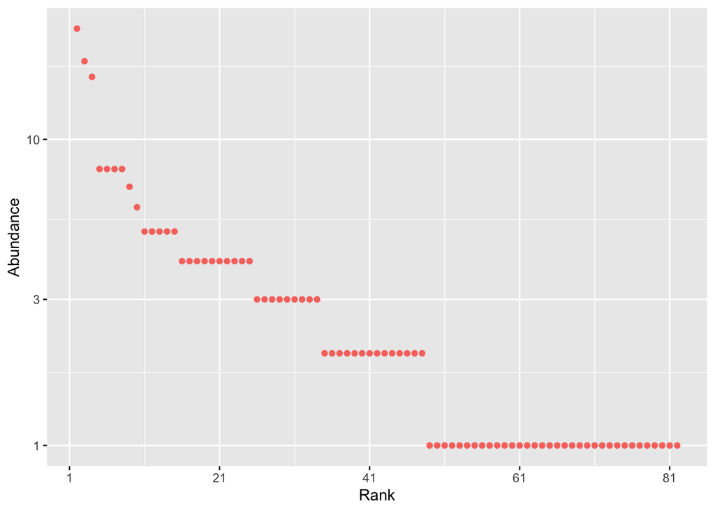

```r
# Choose the size of the community
c_size <- 256
# Draw a random community according to the abundances of the metacommunity
rspcommunity(
  # Draw 1 community
  1,
  # Number of trees
  size = c_size,
  # Metacommunity abundances, must be a vector
  abd = as.numeric(mc_abundances),
  # Draw a multinomial distribution
  bootstrap = "Marcon2012",
  # Random location
  spatial = "Binomial"
  ) ->
  # The result is a weighted, marked, planar point pattern
  c_wmppp

# Show the RAC
c_wmppp %>%
  # Make it an abundances object
  as_abundances() %>%
  autoplot()
```

# Demographic drift

## Map the point pattern

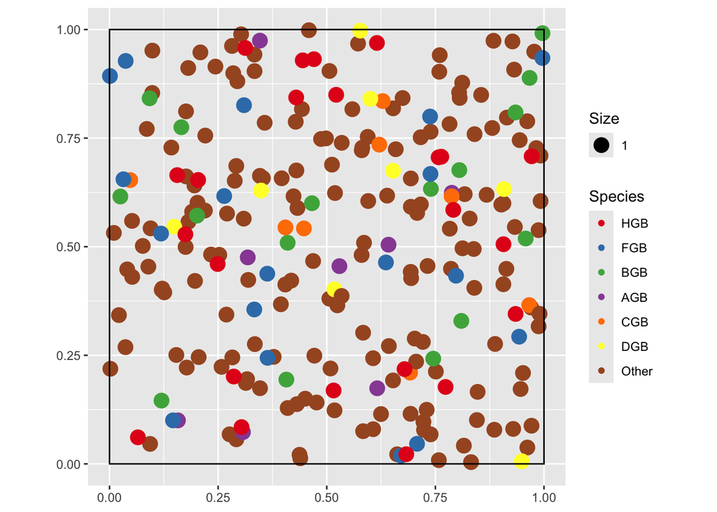

```r
autoplot(c_wmppp) +
  labs(colour = "Species", size = "Size")
```

The drift model is as follows: at each step, a tree dies and is replaced by a new tree from the species of the community, with respect to their probabilities.

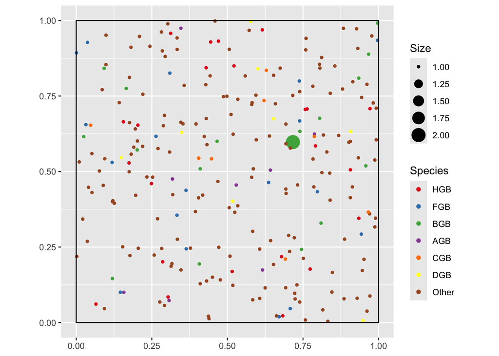

```
## Marked planar point pattern: 256 points
## Mark variables: PointType, PointWeight
## window: rectangle = [0, 1] x [0, 1] units
```

```r
library("dbmss")
#' One-step evolution of a community without migration
#'
#' @param community A wmppp object (package dbmss) where points are trees.
#' @param show If TRUE, a map of the evolved community is produced.
#'
#' @return A wmppp object with the modified community.
evolve_drift <- function(community, show = FALSE) {
  # Choose a tree
  focus_tree <- sample(seq_len(community$n), size = 1)
  # Species of the survivors
  survivors_sp <- marks(community)$PointType[-focus_tree]
  # Draw the species of the new tree
  marks(community)$PointType[focus_tree] <-
    survivors_sp[sample(seq_along(survivors_sp), size = 1)]
  if (show) {
    # Copy the community
    community_to_plot <- community
    # Increase the size of the modified tree
    marks(community_to_plot)$PointWeight[focus_tree] <- 2
    # Plot the community (print is mandatory inside a function)
    print(
      autoplot(community_to_plot) + labs(colour = "Species", size = "Size")
    )
  }
  # return
  return(community)
}

# Test the function
c_wmppp %>%
  evolve_drift(show = TRUE)
```

Drift causes the local extinction of all species but one.

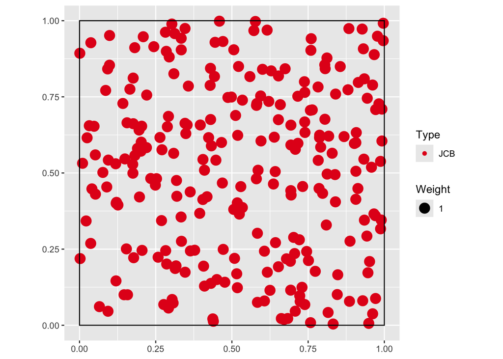

```r
library("cli")
# Copy the community to modify it
the_community <- c_wmppp
# Number of species
richness <- length(unique(marks(the_community)$PointType))
# Prepare a long vector to save the richness along time
richness_time <- numeric(1E6)
# Count the steps
step <- 0
# Prepare a progress bar
if (interactive()) cli_progress_bar("Drifting")
while (richness > 1) {
  step <- step + 1
  # Replace a tree
  the_community <- evolve_drift(the_community)
  # Update the richness
  richness <- length(unique(marks(the_community)$PointType))
  # Save it
  richness_time[step] <- richness
  # Show the progress
   if (interactive()) cli_progress_update()
}
# Finalise the progress bar
if (interactive()) cli_progress_update(force = TRUE)
# Save the necessary time to reach a single species
drift_time <- step
# Plot the community
autoplot(the_community)
```

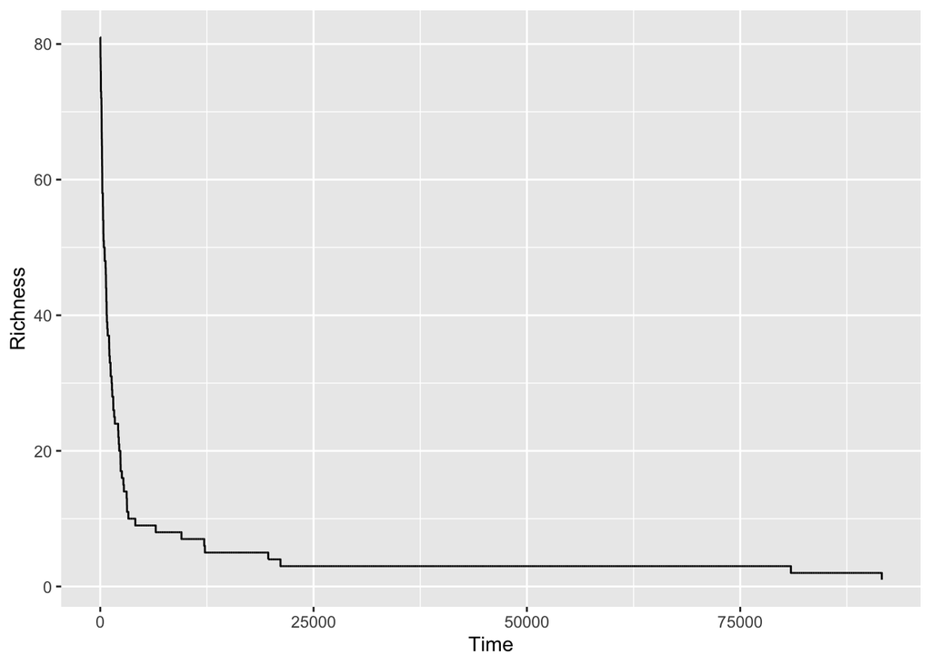

```r
# Plot the decreasing richness
data.frame(Time = seq_len(step), Richness = richness_time[seq_len(step)]) %>%
  ggplot() +
  geom_line(aes(x = Time, y = Richness))
```

# Immigration

Immigration is the ability to replace the dead tree in the local community by a tree of a species of the metacommunity.

The parameter `m` is the probability for that to happen. The evolution function is rewritten.

```r
#' One-step evolution of a community with migration
#'
#' @param community A wmppp object (package dbmss) where points are trees.
#' @param metacommunity A species_distribution object (package divent) that describes the metacommunity.
#' @param m The migration parameter, that is the probability for a dead tree to be replaced by an immigrant species.
#'
#' @return A wmppp object with the modified community.
evolve_migrate <- function(community, metacommunity, m = 0) {
  # Choose a tree
  focus_tree <- sample(seq_len(community$n), size = 1)
  # Migration or local parent? Draw in a uniform distribution.
  u <- runif(1)
  if (u > m) {
    # Local parent: Species of the survivors
    survivors_sp <- marks(community)$PointType[-focus_tree]
    # Draw the species of the new tree
    marks(community)$PointType[focus_tree] <-
      survivors_sp[sample(seq_along(survivors_sp), size = 1)]
  } else {
    # Metacommunity species names
    sp_names <- colnames(abd_species(metacommunity))
    # Metacommunity species abundances
    sp_abd <- as.numeric(metacommunity)
    # Draw a species in the metacommunity:
    # a vector of species abd with a single value 1
    mc_1_tree <- rmultinom(1, size = 1, prob = sp_abd)
    # Set the new species
    marks(community)$PointType[focus_tree] <- sp_names[mc_1_tree == 1]
  }
  # return
  return(community)
}
```

We make the community evolve the same amount of time as needed for complete drift and see what happens.

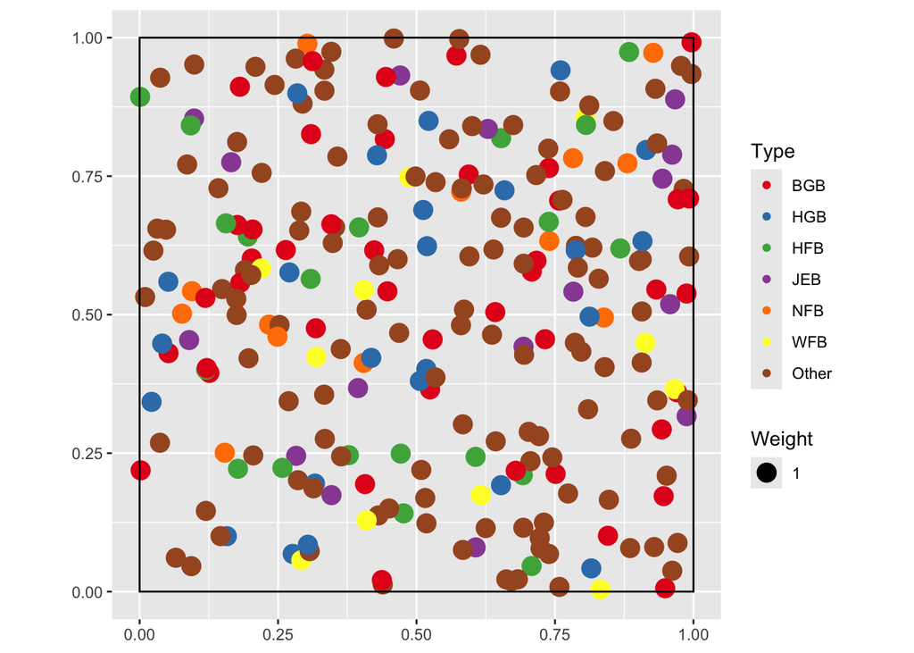

```r
# Choose the migration probability
m <- 0.1

# Copy the community to modify it
the_community <- c_wmppp
# Prepare a long vector to save the richness along time
richness_time <- numeric(drift_time)
# Prepare a progress bar
if (interactive()) {
  cli_progress_bar(paste("Migration", m, ":"), total = drift_time)
}
for (step in seq_len(drift_time)) {
  # Replace a tree
  the_community <- evolve_migrate(the_community, mc_abundances, m)
  # Save the richness
  richness_time[step] <- length(unique(marks(the_community)$PointType))
  # Show the progress
  if (interactive()) cli_progress_update()
}
autoplot(the_community)
```

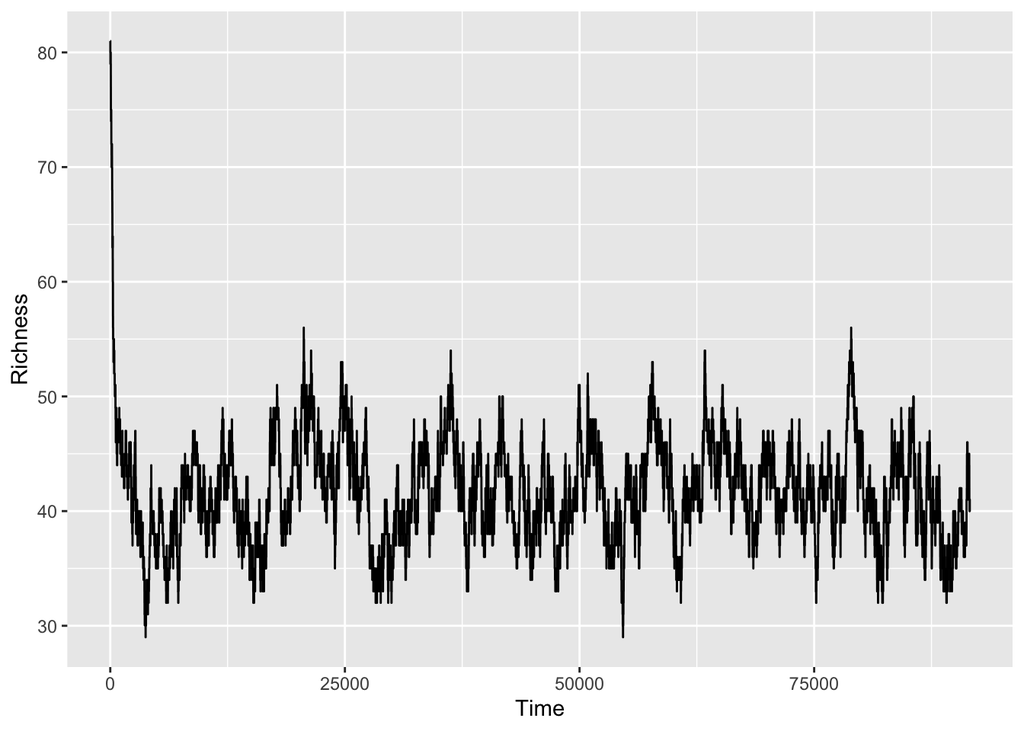

```r
# Plot richness along time
data.frame(
  Time = seq_len(drift_time),
  Richness = richness_time
  ) %>%
  ggplot() +
  geom_line(aes(x = Time, y = Richness))
```

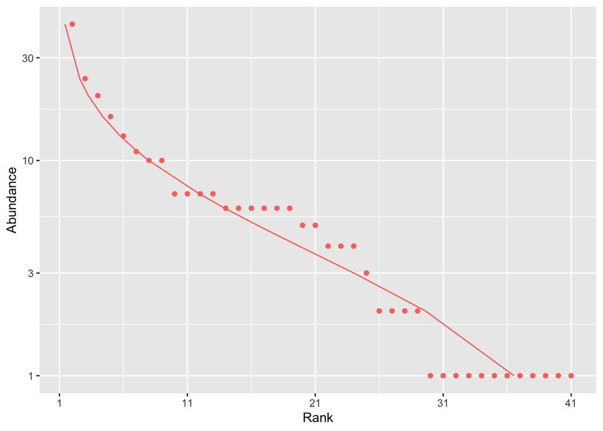

```r
# Plot the rank-abundance curve
the_community %>%
  # Make it an abundance object (package divent)
  as_abundances() %>%
  # Plot the rank-abundance curve and try to fit a log-normal distribution
  autoplot(distribution = "lnorm", fit_rac = TRUE)
```

The average number of species can be calculated from the data, after eliminating the burn-in steps (i.e. before the pattern is stable).

```r
mean(richness_time[10000:drift_time])
```

```
## [1] 41.69635
```

The equation for the expected number of species is in Etienne and Alonso (2007, eq. 4) but it requires knowing the size of the metacommunity.

The minimum richness is 29.

# Exercises

Re-use the code above to run a few experiments about drift time and the shape of the local community.

## The immigration parameter

From the BCI metacommunity, draw a local 1-ha community. Choose two immigration rates in turn: 0.1, as observed at BCI, and 0.01. Run 50,000 steps and observe the final RAC. Compare the number of species with the actual value.

BCI data is available in package vegan.

```r
library("vegan")
data(BCI)
# Number of trees per ha
sum(BCI)/50
```

```
## [1] 429.14
```

```r
# Number of trees in each 1-ha plot
rowSums(BCI)
```

```
##   1   2   3   4   5   6   7   8   9  10  11  12  13  14  15  16  17  18  19  20
## 448 435 463 508 505 412 416 431 409 483 401 366 409 438 462 437 381 347 433 429
##  21  22  23  24  25  26  27  28  29  30  31  32  33  34  35  36  37  38  39  40
## 408 418 340 392 442 407 417 387 364 475 421 459 436 447 601 430 435 447 424 489
##  41  42  43  44  45  46  47  48  49  50
## 402 414 407 409 444 430 425 415 427 432
```

```r
# Number of species in each 1-ha plot
rowSums(BCI > 0)
```

```
##   1   2   3   4   5   6   7   8   9  10  11  12  13  14  15  16  17  18  19  20
##  93  84  90  94 101  85  82  88  90  94  87  84  93  98  93  93  93  89 109 100
##  21  22  23  24  25  26  27  28  29  30  31  32  33  34  35  36  37  38  39  40
##  99  91  99  95 105  91  99  85  86  97  77  88  86  92  83  92  88  82  84  80
##  41  42  43  44  45  46  47  48  49  50
## 102  87  86  81  81  86 102  91  91  93
```

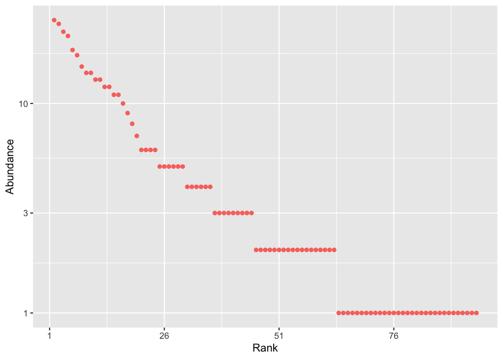

```r
# RAC of plot 1
BCI[1, ] %>%
  as_abundances %>%
  autoplot()
```

## The effect of the size of the local community to drift

Draw small communities with 10 species, in log-normal distributions, ignoring the metacommunity. Make their size vary: 16, 32, 64, 128, 256 individuals. Run the drift model and note the necessary time for complete drift. Compare your results with figure 4.12 (page 106) of Hubbell (2001).

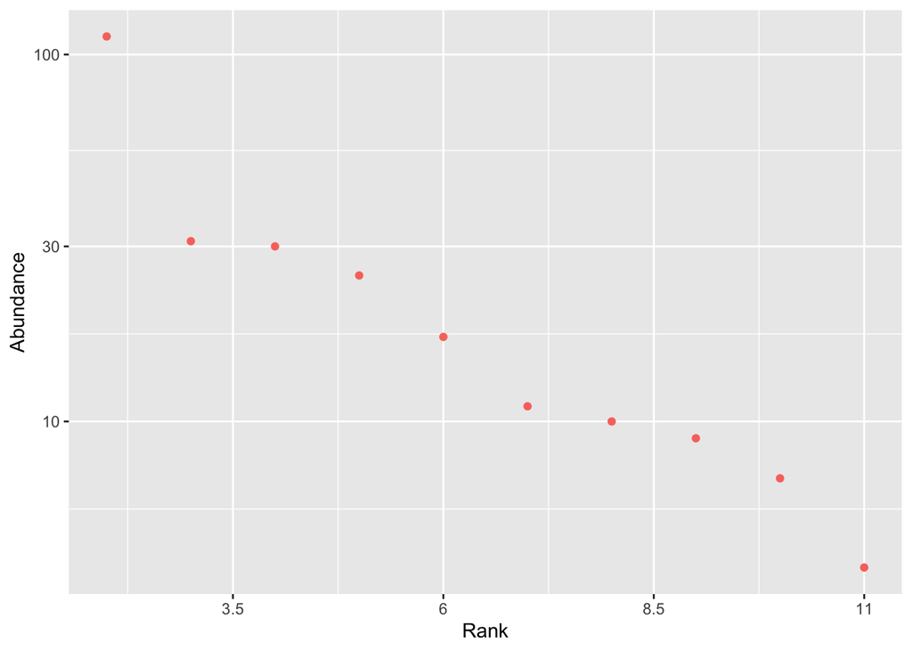

```r
# Hint
rcommunity(1, size = 256, species_number = 10) %>%
  autoplot()
```

# References

Etienne, Rampal S., and David Alonso. 2007. “Neutral Community Theory: How Stochasticity and Dispersal-Limitation Can Explain Species Coexistence.” *Journal of Statistical Physics* 128 (1-2): 485–510. https://doi.org/10.1007/s10955-006-9163-2.

Fisher, Ronald Aylmer, A. Steven Corbet, and Carrington Bonsor Williams. 1943. “The Relation Between the Number of Species and the Number of Individuals in a Random Sample of an Animal Population.” *Journal of Animal Ecology* 12: 42–58. https://doi.org/10.2307/1411.

Hubbell, Stephen P. 2001. *The Unified Neutral Theory of Biodiversity and Biogeography*. Princeton University Press.

ter Steege, Hans, Nigel C. A. Pitman, Daniel Sabatier, et al. 2013. “Hyperdominance in the Amazonian Tree Flora.” *Science* 342 (6156): 1243092. https://doi.org/10.1126/science.1243092.